# Lab 2: Graphing MLS Salaries with ggplot

Alison Polito

2023-10-02

### 0. Loard libraries and data.

### 0. Doh. Looks like we have some column names that need cleaning.

### 0. Rename any of those columns that you can make shorter without making them less clear.

### 0. We don’t need to take this data out to coffee because we already got to know it.

### 1. Make a scatterplot showing that helps us see whether there’s any relationship between base salary and guaranteed compensation.

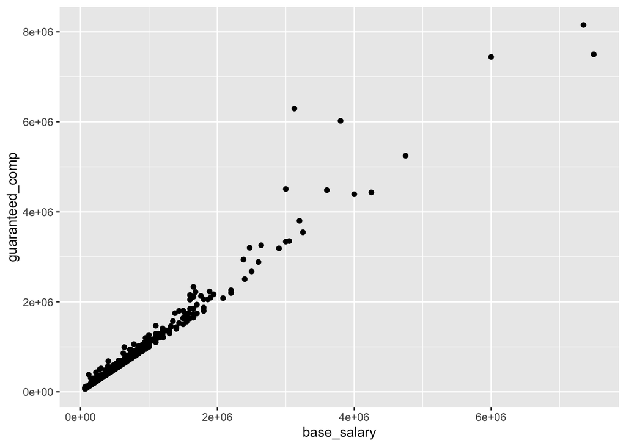

### 2. I wonder what position those outliers are. Let’s make that same graph, but color each dot by position.

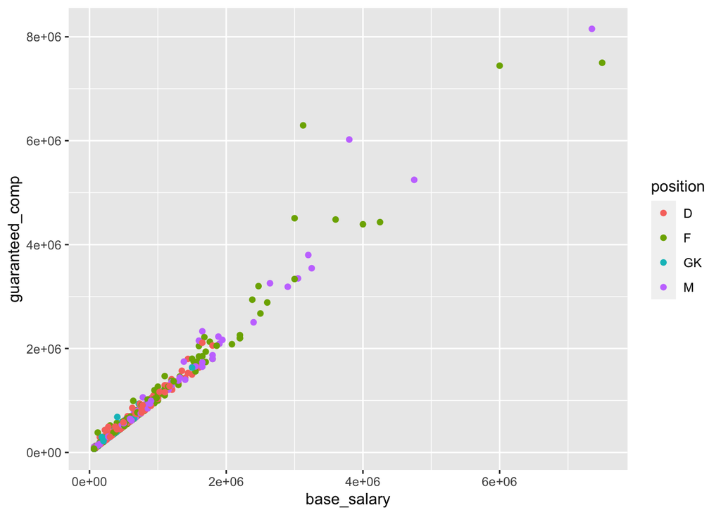

### 3. The trend here looks pretty obivous, but lets add a (essentially) line of best fit along a (essentially) rolling mean. And, yes, I’m talking here about geom_smooth()

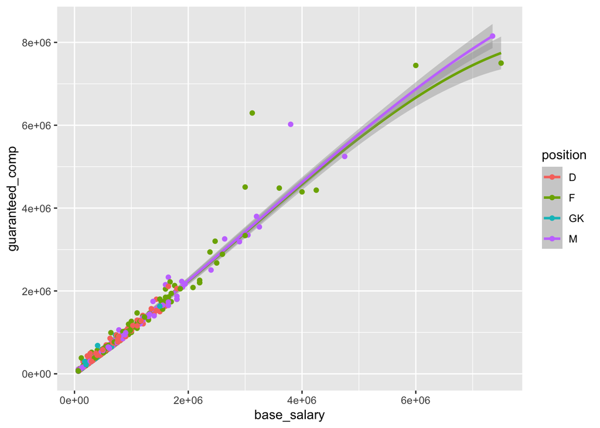

### 4. Those points at the lower left are all on top of each other. Let’s change their opacity to 20%.

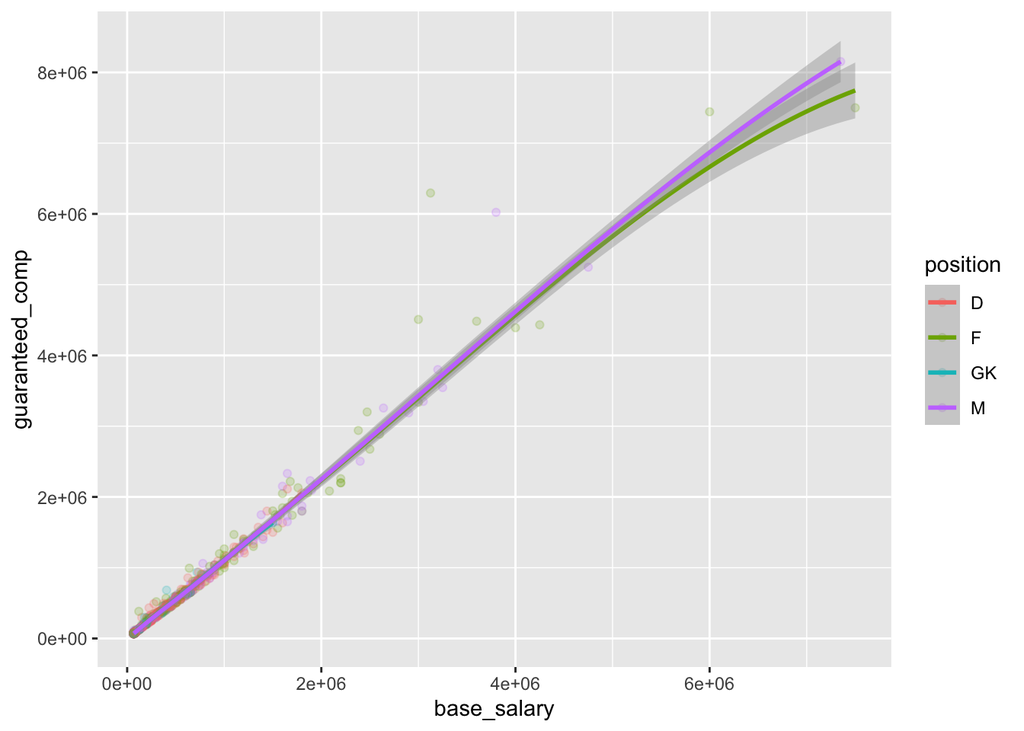

### 5. There seems to be a skewed distribution of salaries. Let’s make a histogram of base salaries to see if that gives us any more detailed insights.

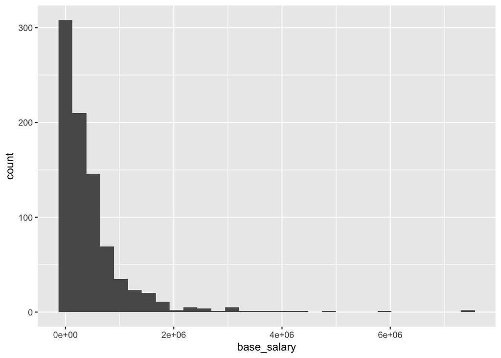

### 6. Let’s color AND fill that histogram by team.

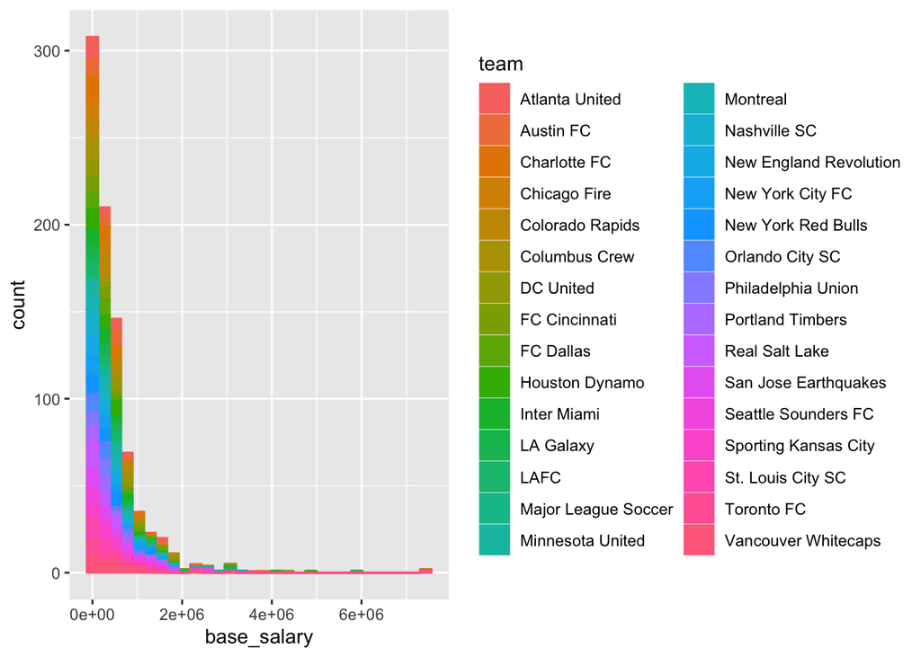

### 7. It’s hard to see what’s going on there. Let’s color it by position instead, and maybe dodge the position of the bars to help us differentiate between positions.

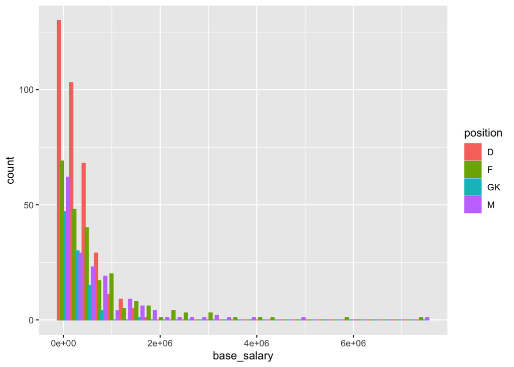

### 8. Let’s make a bar chart that shows us the number of players by each position.

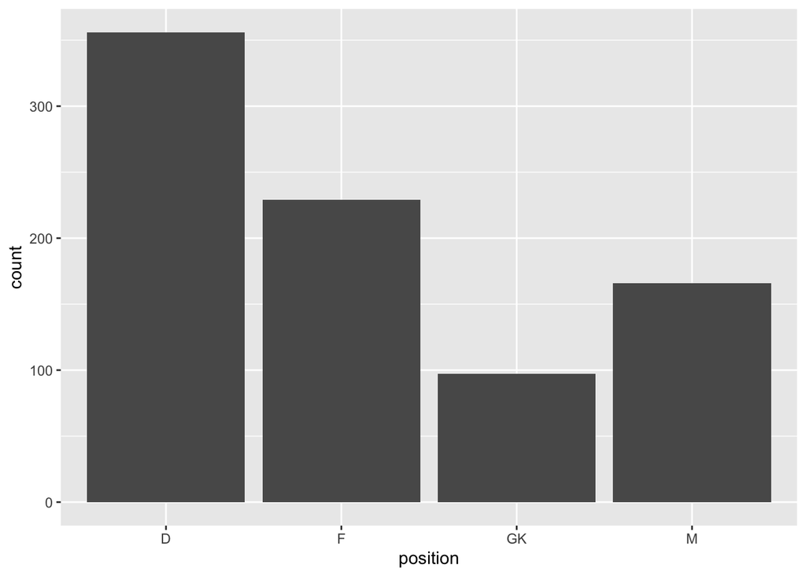

### 9. Rather than try to compare all the salaries of all the players at each position, it would be good to look at the average salary by position. To do that we first need to do some grouping and then draw the chart.

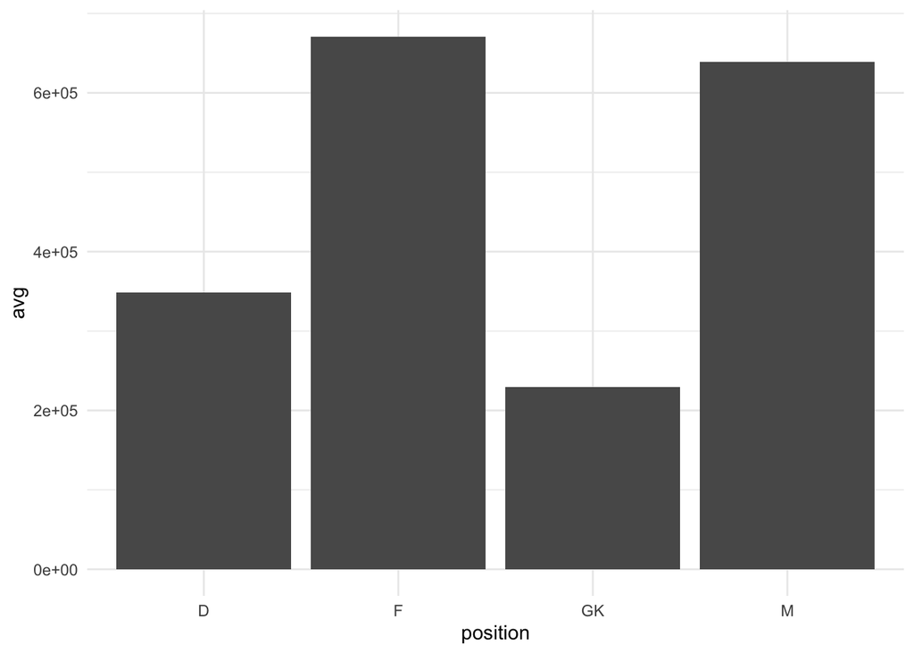

### 10. Let’s extend ggplot by installing the ggthemes package and giving our last graph a `theme_wsj`

*All the available ggthemes at https://exts.ggplot2.tidyverse.org/ggthemes.html

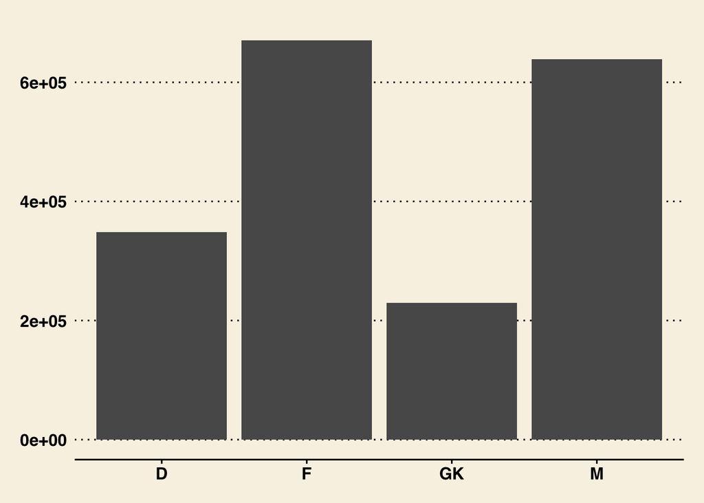

### 11. Let’s use a pre-built dumbbell geom as well as the sanity-saving scales package to make something pretty.

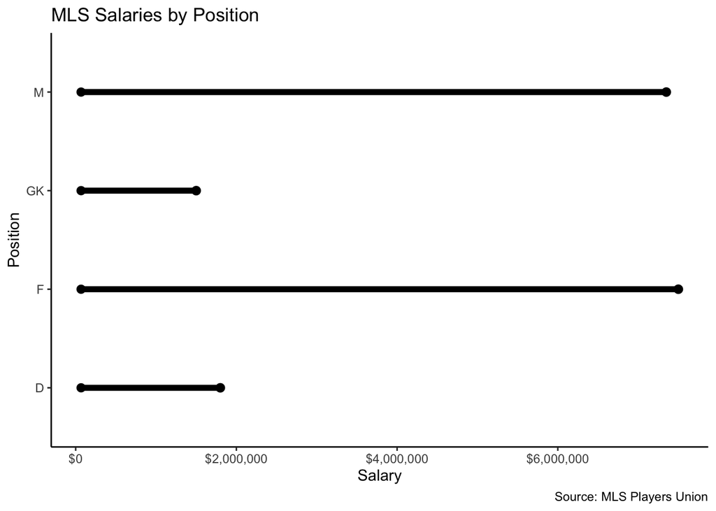